# EDA on Red Wine Quality

> by Tony Bastin

# Abstract

The purpose of this project is to explore the quality of red wine on the basis of its chemical properties. The study is carried out with help of the statistical program, RStudio. A brief description of the dataset can be seen [here](https://s3.amazonaws.com/udacity-hosted-downloads/ud651/wineQualityInfo.txt).

```
## 'data.frame':    1599 obs. of  13 variables:
##  $ X                   : int  1 2 3 4 5 6 7 8 9 10 ...
##  $ fixed.acidity       : num  7.4 7.8 7.8 11.2 7.4 7.4 7.9 7.3 7.8 7.5 ...
##  $ volatile.acidity    : num  0.7 0.88 0.76 0.28 0.7 0.66 0.6 0.65 0.58 0.5 ...
##  $ citric.acid         : num  0 0 0.04 0.56 0 0 0.06 0 0.02 0.36 ...
##  $ residual.sugar      : num  1.9 2.6 2.3 1.9 1.9 1.8 1.6 1.2 2 6.1 ...
##  $ chlorides           : num  0.076 0.098 0.092 0.075 0.076 0.075 0.069 0.065 0.073 0.071 ...
##  $ free.sulfur.dioxide : num  11 25 15 17 11 13 15 15 9 17 ...
##  $ total.sulfur.dioxide: num  34 67 54 60 34 40 59 21 18 102 ...
##  $ density             : num  0.998 0.997 0.997 0.998 0.998 ...
##  $ pH                  : num  3.51 3.2 3.26 3.16 3.51 3.51 3.3 3.39 3.36 3.35 ...
##  $ sulphates           : num  0.56 0.68 0.65 0.58 0.56 0.56 0.46 0.47 0.57 0.8 ...
##  $ alcohol             : num  9.4 9.8 9.8 9.8 9.4 9.4 9.4 10 9.5 10.5 ...
##  $ quality             : int  5 5 5 6 5 5 5 7 7 5 ...
```

```
##        X          fixed.acidity   volatile.acidity  citric.acid
##  Min.   :   1.0   Min.   : 4.60   Min.   :0.1200   Min.   :0.000
##  1st Qu.: 400.5   1st Qu.: 7.10   1st Qu.:0.3900   1st Qu.:0.090
##  Median : 800.0   Median : 7.90   Median :0.5200   Median :0.260
##  Mean   : 800.0   Mean   : 8.32   Mean   :0.5278   Mean   :0.271
##  3rd Qu.:1199.5   3rd Qu.: 9.20   3rd Qu.:0.6400   3rd Qu.:0.420
##  Max.   :1599.0   Max.   :15.90   Max.   :1.5800   Max.   :1.000
##  residual.sugar     chlorides       free.sulfur.dioxide
##  Min.   : 0.900   Min.   :0.01200   Min.   : 1.00
##  1st Qu.: 1.900   1st Qu.:0.07000   1st Qu.: 7.00
##  Median : 2.200   Median :0.07900   Median :14.00
##  Mean   : 2.539   Mean   :0.08747   Mean   :15.87
##  3rd Qu.: 2.600   3rd Qu.:0.09000   3rd Qu.:21.00
##  Max.   :15.500   Max.   :0.61100   Max.   :72.00
##  total.sulfur.dioxide    density             pH          sulphates
##  Min.   :  6.00       Min.   :0.9901   Min.   :2.740   Min.   :0.3300
##  1st Qu.: 22.00       1st Qu.:0.9956   1st Qu.:3.210   1st Qu.:0.5500
##  Median : 38.00       Median :0.9968   Median :3.310   Median :0.6200
##  Mean   : 46.47       Mean   :0.9967   Mean   :3.311   Mean   :0.6581
##  3rd Qu.: 62.00       3rd Qu.:0.9978   3rd Qu.:3.400   3rd Qu.:0.7300
##  Max.   :289.00       Max.   :1.0037   Max.   :4.010   Max.   :2.0000
##     alcohol         quality
##  Min.   : 8.40   Min.   :3.000
##  1st Qu.: 9.50   1st Qu.:5.000
##  Median :10.20   Median :6.000
##  Mean   :10.42   Mean   :5.636
##  3rd Qu.:11.10   3rd Qu.:6.000
##  Max.   :14.90   Max.   :8.000
```

A few points observed from the summary and structure of the dataset :

- The dataset contains 1599 observations with 13 variables.
- As per the description, there are supposed to be only 11 chemical properties and one result quality of the wine resulting in a total of only 12 variables. The 13th variable “X” appears to be the indexing and will be removed from the dataset before further investigation.
- All the 11 chemical properties of redwine are continous variables.
- The quality of red wine is an ordered categorical variable and will be converted accordingly in the dataframe.

The structure and summary of the dataset after doing the above mentioned changes are as given below :

```
## 'data.frame':    1599 obs. of  12 variables:
##  $ fixed.acidity       : num  7.4 7.8 7.8 11.2 7.4 7.4 7.9 7.3 7.8 7.5 ...
##  $ volatile.acidity    : num  0.7 0.88 0.76 0.28 0.7 0.66 0.6 0.65 0.58 0.5 ...
##  $ citric.acid         : num  0 0 0.04 0.56 0 0 0.06 0 0.02 0.36 ...
##  $ residual.sugar      : num  1.9 2.6 2.3 1.9 1.9 1.8 1.6 1.2 2 6.1 ...
##  $ chlorides           : num  0.076 0.098 0.092 0.075 0.076 0.075 0.069 0.065 0.073 0.071 ...
##  $ free.sulfur.dioxide : num  11 25 15 17 11 13 15 15 9 17 ...
##  $ total.sulfur.dioxide: num  34 67 54 60 34 40 59 21 18 102 ...
##  $ density             : num  0.998 0.997 0.997 0.998 0.998 ...
##  $ pH                  : num  3.51 3.2 3.26 3.16 3.51 3.51 3.3 3.39 3.36 3.35 ...
##  $ sulphates           : num  0.56 0.68 0.65 0.58 0.56 0.56 0.46 0.47 0.57 0.8 ...
##  $ alcohol             : num  9.4 9.8 9.8 9.8 9.4 9.4 9.4 10 9.5 10.5 ...
##  $ quality             : Ord.factor w/ 6 levels "3"<"4"<"5"<"6"<..: 3 3 3 4 3 3 3 5 5 3 ...
```

```
##  fixed.acidity   volatile.acidity  citric.acid    residual.sugar
##  Min.   : 4.60   Min.   :0.1200   Min.   :0.000   Min.   : 0.900
##  1st Qu.: 7.10   1st Qu.:0.3900   1st Qu.:0.090   1st Qu.: 1.900
##  Median : 7.90   Median :0.5200   Median :0.260   Median : 2.200
##  Mean   : 8.32   Mean   :0.5278   Mean   :0.271   Mean   : 2.539
##  3rd Qu.: 9.20   3rd Qu.:0.6400   3rd Qu.:0.420   3rd Qu.: 2.600
##  Max.   :15.90   Max.   :1.5800   Max.   :1.000   Max.   :15.500
##    chlorides       free.sulfur.dioxide total.sulfur.dioxide
##  Min.   :0.01200   Min.   : 1.00       Min.   :  6.00
##  1st Qu.:0.07000   1st Qu.: 7.00       1st Qu.: 22.00
##  Median :0.07900   Median :14.00       Median : 38.00
##  Mean   :0.08747   Mean   :15.87       Mean   : 46.47
##  3rd Qu.:0.09000   3rd Qu.:21.00       3rd Qu.: 62.00
##  Max.   :0.61100   Max.   :72.00       Max.   :289.00
##     density             pH          sulphates         alcohol      quality
##  Min.   :0.9901   Min.   :2.740   Min.   :0.3300   Min.   : 8.40   3: 10
##  1st Qu.:0.9956   1st Qu.:3.210   1st Qu.:0.5500   1st Qu.: 9.50   4: 53
##  Median :0.9968   Median :3.310   Median :0.6200   Median :10.20   5:681
##  Mean   :0.9967   Mean   :3.311   Mean   :0.6581   Mean   :10.42   6:638
##  3rd Qu.:0.9978   3rd Qu.:3.400   3rd Qu.:0.7300   3rd Qu.:11.10   7:199
##  Max.   :1.0037   Max.   :4.010   Max.   :2.0000   Max.   :14.90   8: 18
```

# Univariate Plots Section

The histograms of all the 12 variables were made to get an idea of their distributions:

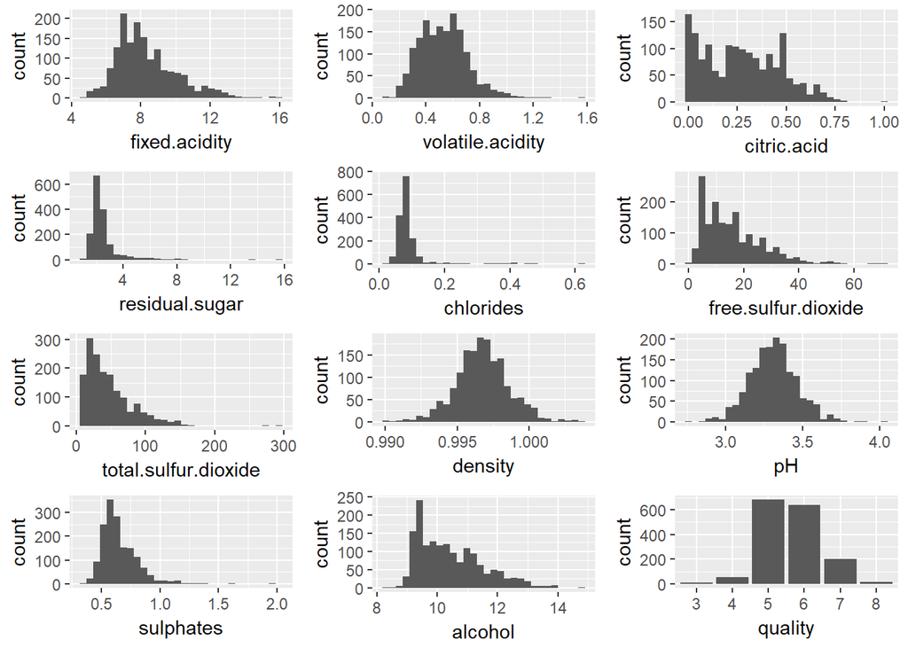

From the above histograms, we can comment on the skewness of the 11 chemical properties as below:

- Normal distribution: Volatile Acidity, Density, PH
- Long tailed positively skewed distribution: Fixed Acidity, Free Sulfur Dioxide, Total Sulfur Dioxide, Sulphates, Alcohol
- Residual sugar, Chlorides have extreme outliers
- Citric acid have a large number of zero values

Skewed and long tailed data can be converted into normal distributions by transformig the data using either sqrt or log10 transformation. We will apply the transformations on a few variables and the histograms before and after transformations are shown below:

1. Sulphates :

The application of log10 transformation on sulphates have transformed it into a normal distribution

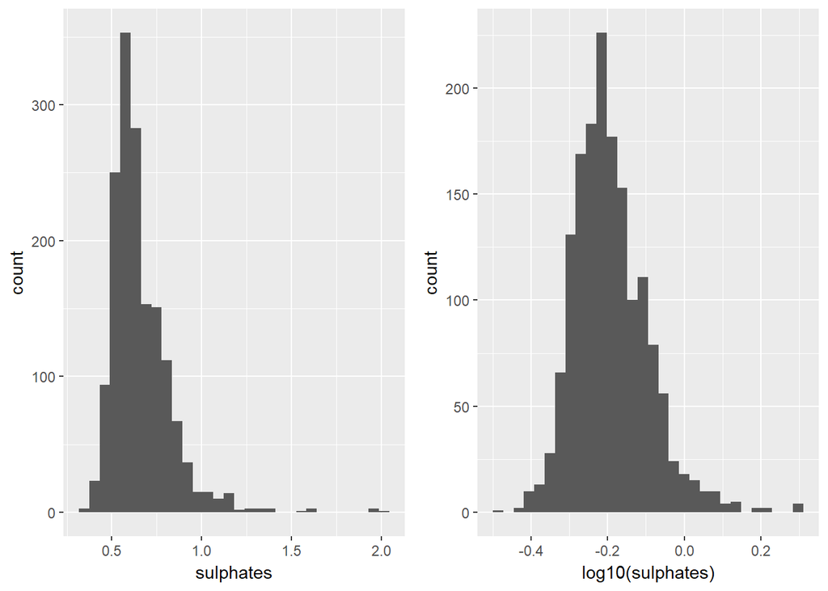

2. Total sulphur dioxide :

The application of log10 transformation on total sulphur dioxide have transformed it into a normal distribution

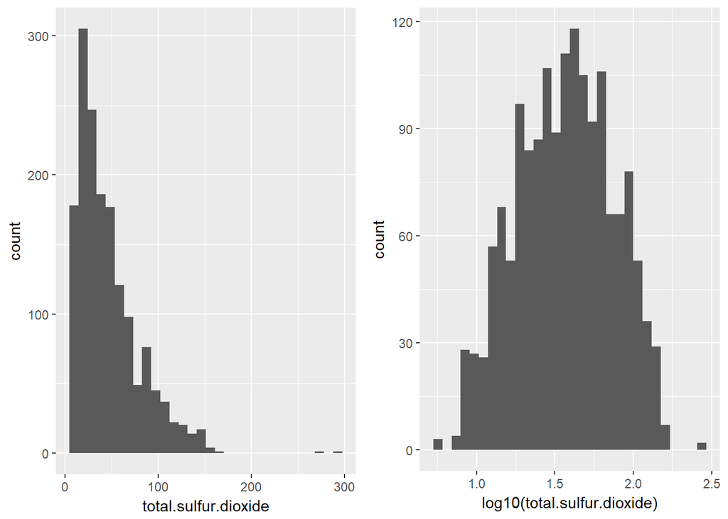

3. Fixed acidity :

The application of sqrt transformation on fixed acidity have transformed it into a normal distribution with a few outliers.

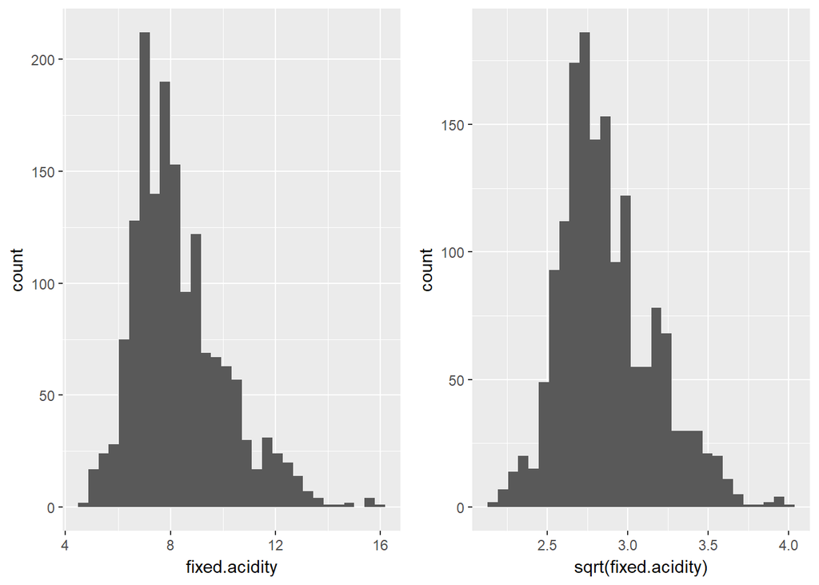

The red wines were given different ratings based on their quality into ‘bad’, ‘average’ and ‘good’. This will help a lot in future visualizations. From the below table and bar chart, it is evedent that most of the wines (1319) belong to the average category and only a few number (217) gets into the category of good quality wines.

```
##
##     bad average    good
##      63    1319     217
```

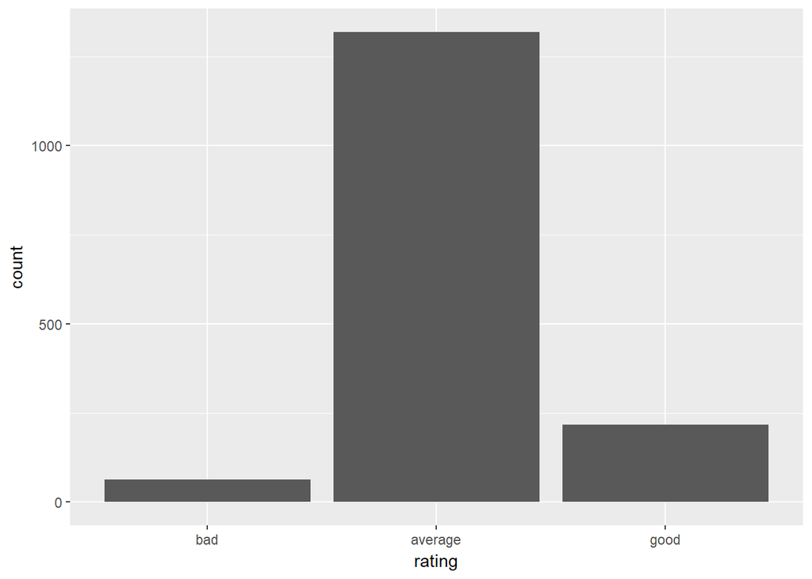

# Univariate Analysis

### What is/are the main feature(s) of interest in your dataset?

The main feature of interest is the quality of redwine and it would be interesting to study how the quality is affected by the other variables.

### What other features in the dataset do you think will help support your investigation into your feature(s) of interest?

I strongly believe that the different measures of acidity ( pH, fixed acidity, volatile acidity, citric acid) and alcholo content will have influence on the quality of wines.

### Did you create any new variables from existing variables in the dataset?

A new variable called rating was introduced which classifies the different wines based on their quality into ‘bad’ (3,4), ‘average’ (5, 6), and ‘good’ (7,8).

### Of the features you investigated, were there any unusual distributions? Did you perform any operations on the data to tidy, adjust, or change the form of the data? If so, why did you do this?

- The variable “X” in the dataframe was removed as it was just used for indexing.
- The quality of red wine is converted into an ordered categorical variable.
- Citric acid was having a lot of zero values, however nothing was done as the reason was not clear.

# Bivariate Plots Section

A correlation plot between the wine quality and each chemical property will help us to understand which factors are affecting the wine qality.

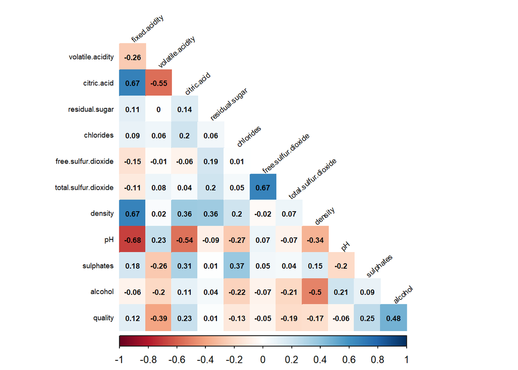

Table below shows the r-values of checmical properties w.r.t wine quality.

```
##       Chemical Property     R-Value
## 1         fixed.acidity  0.12405165
## 2      volatile.acidity -0.39055778
## 3           citric.acid  0.22637251
## 4        residual.sugar  0.01373164
## 5             chlorides -0.12890656
## 6   free.sulfur.dioxide -0.05065606
## 7  total.sulfur.dioxide -0.18510029
## 8               density -0.17491923
## 9                    pH -0.05773139
## 10            sulphates  0.25139708
## 11              alcohol  0.47616632
```

From the above table we can see that the following chemical properties have relatively higher correlations to wine quality:

- alcohol - 0.476
- volatile acidity - 0.391
- sulphates - 0.251
- citric acid - 0.226

To my surpirse, it was noticed that no strong correlation excisted between pH, fixed acidity and wine quality. However, suplates was observed to have higher correlation.

Let us examine how the alchol, volatile acidity, sulphates and citric acid contents effect quality of wine.For this, we will make boxplots and scatter plots as shown below for these 4 chemical propoerties.

1. alchol vs rating

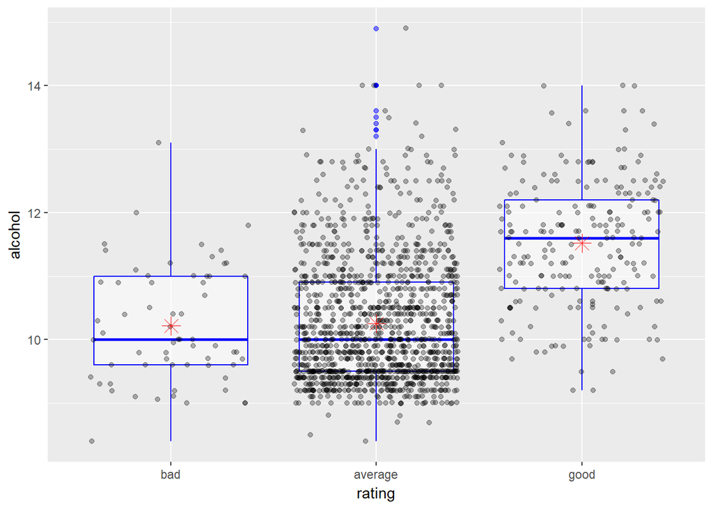

2. volatile acidity vs rating

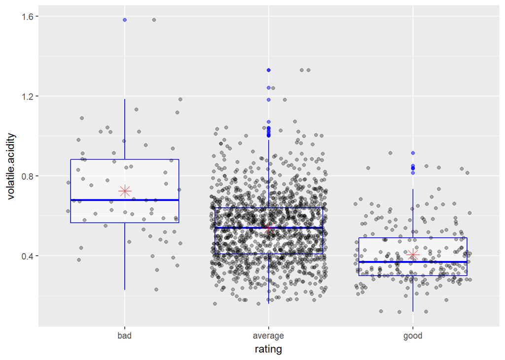

3. sulphates vs rating

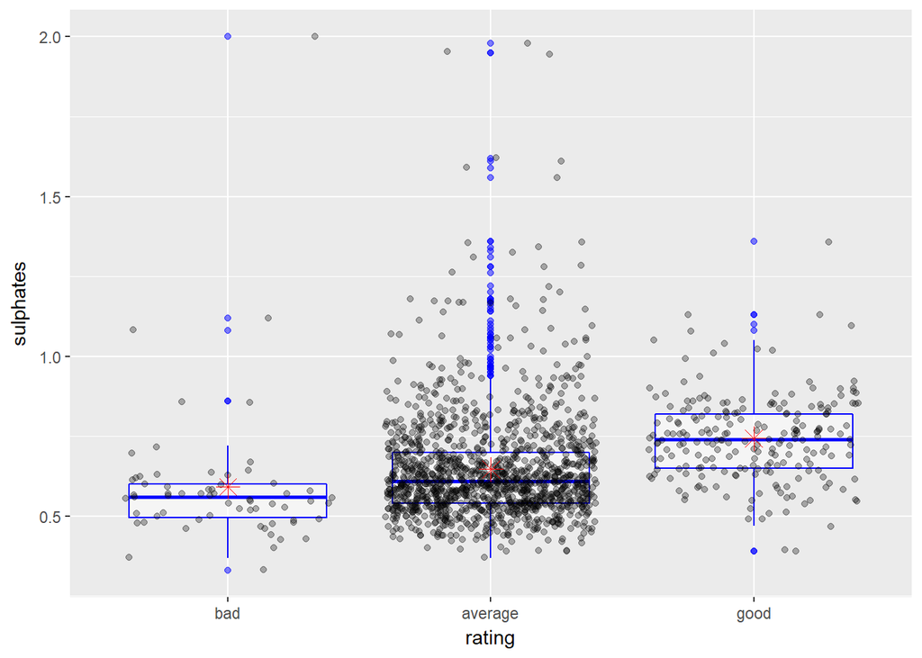

4. citric acid vs rating

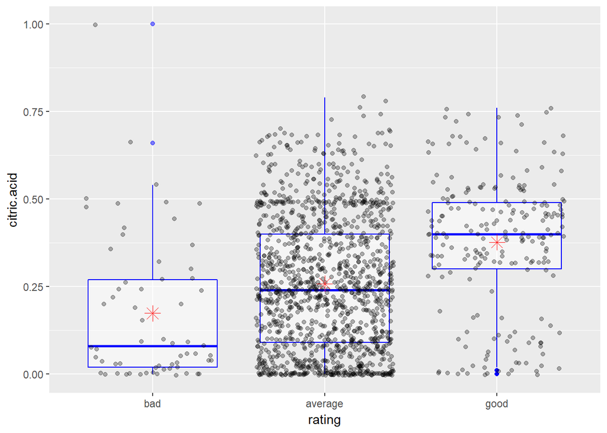

From the above plots, it is evident that good quality wine have higher alcholol, sulphates and citric acid content and low volatile acidity.

Let us also examine, whether any correlation excist between these chemical properties.

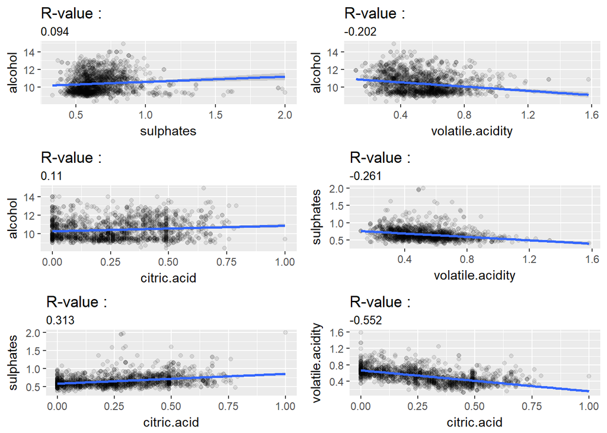

The volatile acididty and citric acid has a strong negative correlation of 0.552 indicating that the higher quantities of volatile acidity means low quantities of citric acid.

It also appears that higher the citric acid content, the higher is the sulphate content which is evident from the positive correlation of 0.313.

# Bivariate Analysis

### Talk about some of the relationships you observed in this part of the investigation. How did the feature(s) of interest vary with other features in the dataset?

- A good quality wine will have higher alcholol, sulphates and citric acid content and low volatile acidity.
- Citric acid and sulphate contents were positievely correlated.
- Citric acid and Volatile acidity was negatively correlatd.

### Did you observe any interesting relationships between the other features (not the main feature(s) of interest)?

- Positive correlation of 0.313 was observed between the citric acid and sulphate content.
- Negative correlation of 0.552 was observed between the citric acid and volatile acidity content

### What was the strongest relationship you found?

A strongest positive correlation of .476 excisted between wine quality and alcohol content. The wine quality increases with the increase in alcohol content.

# Multivariate Plots Section

We can add another dimension into the plot by adding colors. Let us examine the effect of alcohol content and volatile acidity on wine quality . I have also added littele bit jitteer and also alpha parameter to get over oveploatting.

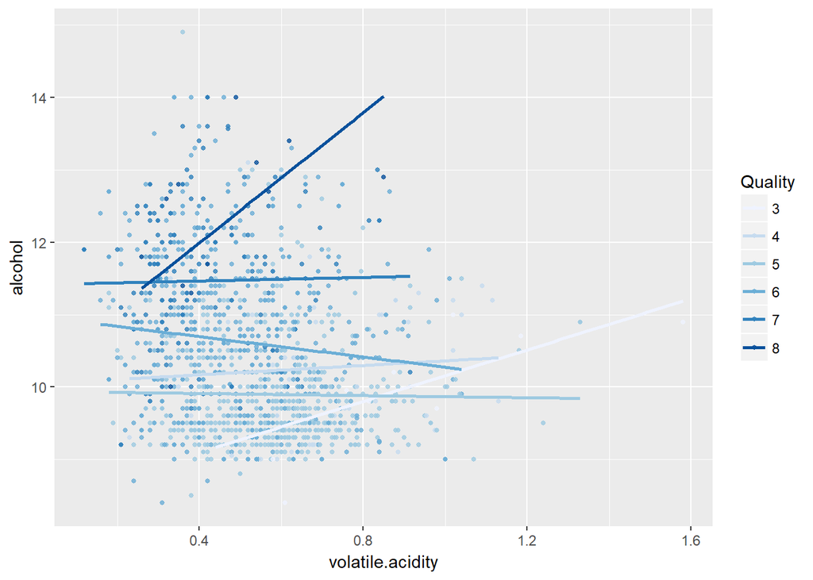

We can add 4th dimension to the plots by adding the wrapping. Lets us examine further the relationship between citric acid and volatile acidity based on quality and rating

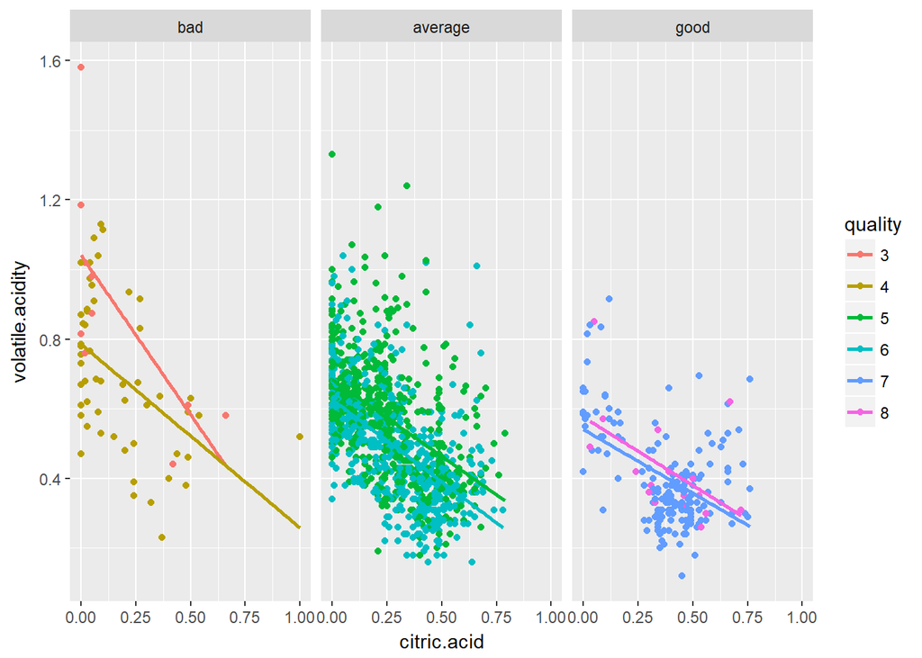

Lets us examine further the relationship between citric acid and sulphate acidity based on quality and rating

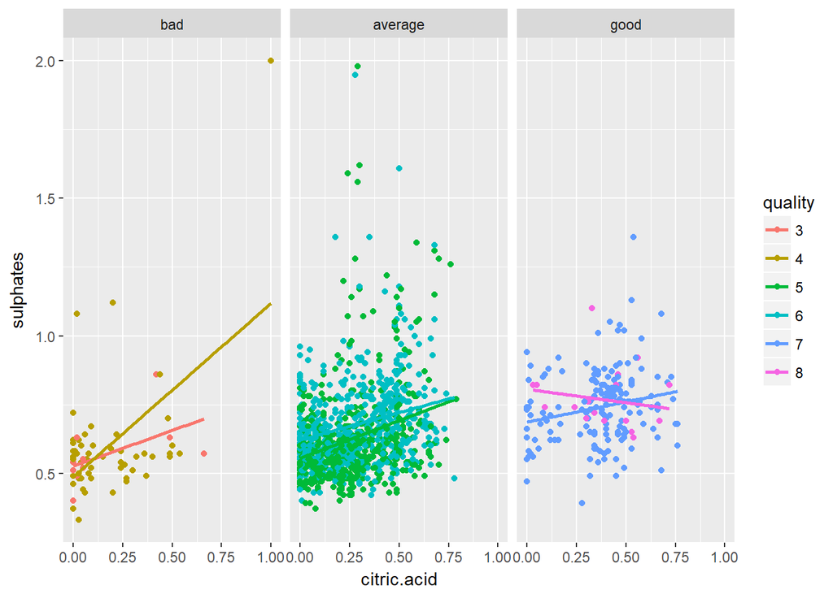

Lets us examine further the relationship between citric acid and pH acidity based on quality and rating

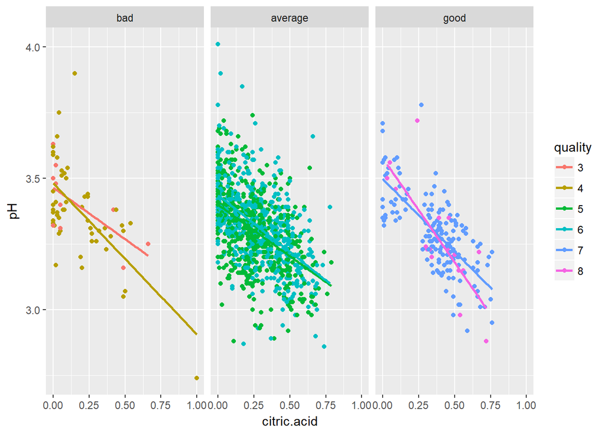

# Linear model

A linear model for quality was created using the four major chemical properties : alcohol, volatile acidity, sulphates and citric acid.The important parameters for the model is also given in thr table below.

```
##
## Calls:
## m1: lm(formula = quality ~ alcohol, data = df1)
## m2: lm(formula = quality ~ alcohol + volatile.acidity, data = df1)
## m3: lm(formula = quality ~ alcohol + volatile.acidity + sulphates,
##     data = df1)
## m4: lm(formula = quality ~ alcohol + volatile.acidity + sulphates +
##     citric.acid, data = df1)
##
## ================================================================
##                        m1         m2         m3         m4
## ----------------------------------------------------------------
##   (Intercept)       -0.125      1.095***   0.611**    0.646**
##                     (0.175)    (0.184)    (0.196)    (0.201)
##   alcohol            0.361***   0.314***   0.309***   0.309***
##                     (0.017)    (0.016)    (0.016)    (0.016)
##   volatile.acidity             -1.384***  -1.221***  -1.265***
##                                (0.095)    (0.097)    (0.113)
##   sulphates                                0.679***   0.696***
##                                           (0.101)    (0.103)
##   citric.acid                                        -0.079
##                                                      (0.104)
## ----------------------------------------------------------------
##   R-squared              0.2        0.3        0.3        0.3
##   adj. R-squared         0.2        0.3        0.3        0.3
##   sigma                  0.7        0.7        0.7        0.7
##   F                    468.3      370.4      268.9      201.8
##   p                      0.0        0.0        0.0        0.0
##   Log-likelihood     -1721.1    -1621.8    -1599.4    -1599.1
##   Deviance             805.9      711.8      692.1      691.9
##   AIC                 3448.1     3251.6     3208.8     3210.2
##   BIC                 3464.2     3273.1     3235.7     3242.4
##   N                   1599       1599       1599       1599
## ================================================================
```

Plotting the error made by the linear model:

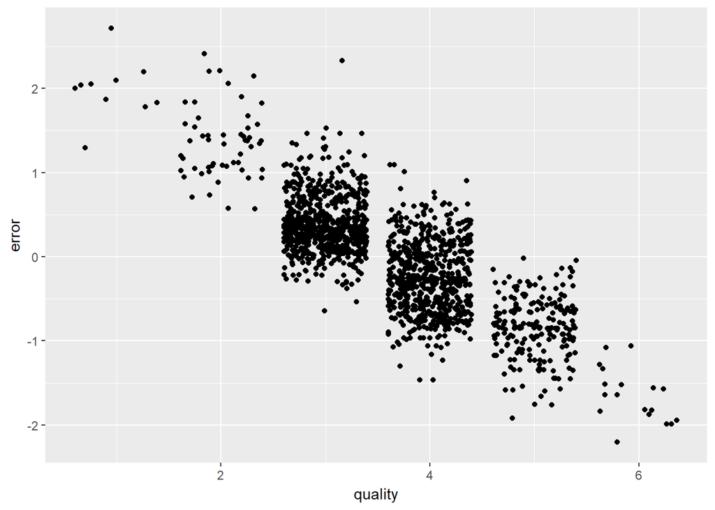

# Multivariate Analysis

### Talk about some of the relationships you observed in this part of the investigation. Were there features that strengthened each other in terms of looking at your feature(s) of interest?

- Low volatile acidity and high alcohol contents seem to produce good quality wines.
- High citric acid and low volatile acidity contents seem to produce good quality wines.
- High sulphate and high achol contents produces good quality wines
- pH levels didn’t seem to influence the quality of wine

### Did you create any models with your dataset? Discuss the strengths and limitations of your model.

A linear model to predict the quality of red wine was made with the four major chemical properties : alcohol, volatile acidity, sulphates and citric acid. The predictions made by the model was off by + or - 2. The limitations of fitting a linear model to this dataset is obvious. We should be using classification algorithams to make the predcictions.

# Final Plots and Summary

### Plot One : Alcohol vs Wine Quality

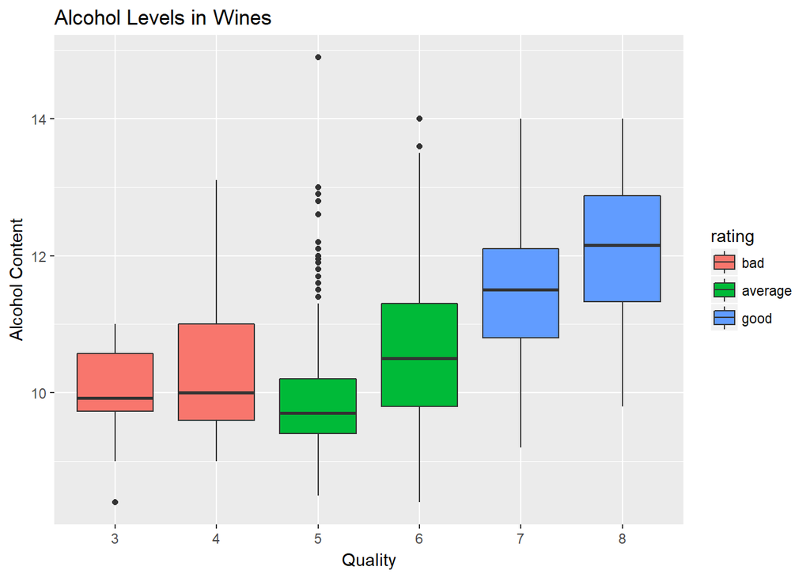

### Description One

The above boxplot revealed that good wines have higher alcohol content in them.

### Plot Two : Acids vs Wine quality

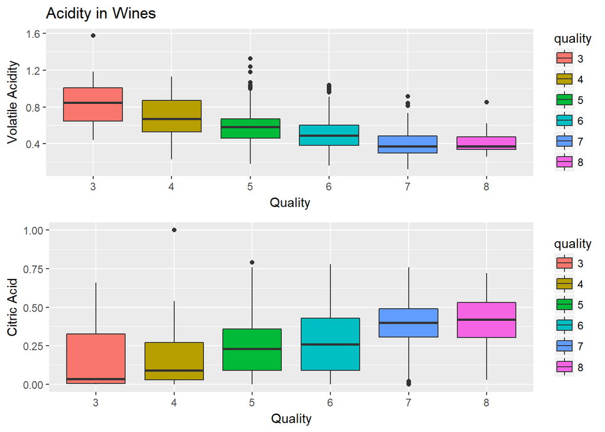

### Plot Three : Effect of alcohol content and volatile acidity on wine quality

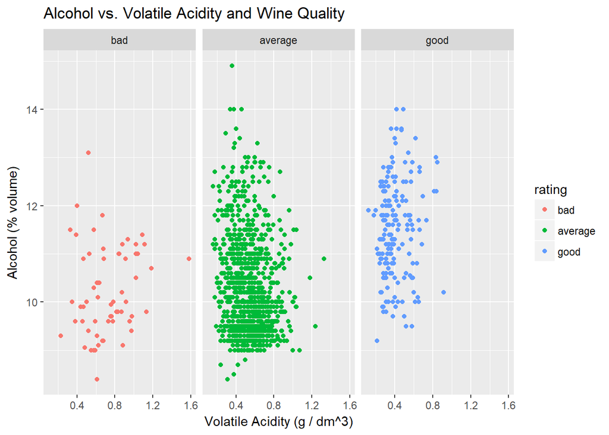

### Description Three

From the above scatter plot, we can clearly make out that good wines have higher alcohol content and low volatile acidity

# Reflection

The red wine data set contains information on the chemical properties of wines.It contains 1,599 observation with 11 variables on the chemical properties.

Most of the viswalizations created also supported the findings from correlation studies.

The linear model created from these four chemical properties made a lot of errors in the prediction since this was a classification problem rather than a regresion one.

One limitations of this study is the source of the data. The red wines selectd for the study was only from Portugal and information about the wine tasters i.e. they are Portugese or Interantional is not given so the qualities reported is not a generalisation for red wines all over the world.

As a further work, I would recommend investigating with inferential statistics to quantitatively confirm these assertions and making prediction using nonlinear regression model and classification algorithms for achieving models with better prediction and accuracy.

# References

https://www.udacity.com/ https://cran.r-project.org/web/packages/corrplot/vignettes/corrplot-intro.html http://www.sthda.com/english/wiki/visualize-correlation-matrix-using-correlogram http://ggplot.yhathq.com/